# A3: Spatial Network

Αντώνιος Νεκτάριος Ντουντούκαλης

15 January, 2025

Μάθημα: Γεωγραφική Ανάλυση

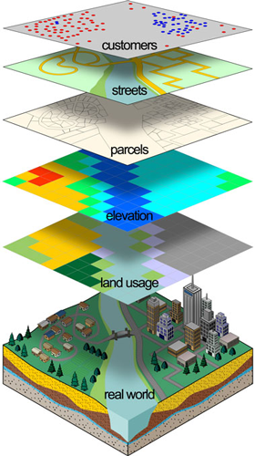

# 1 Δεδομένα δικτύου

Εδώ ορίζουμε το BoundingBox (ΒΒ) των Χανίων. Κατεβάζει οδικό δίκτυο εντός του BB της περιοχής μελέτης.

```r
q = c(23.9639, 35.4894, 24.0611, 35.5322) # Bounding Box πόλης Χανίων
net2 = goal::osm.getRoads(q, withBB=TRUE, outcrs=4326)
```

```
##
## Using bbox
```

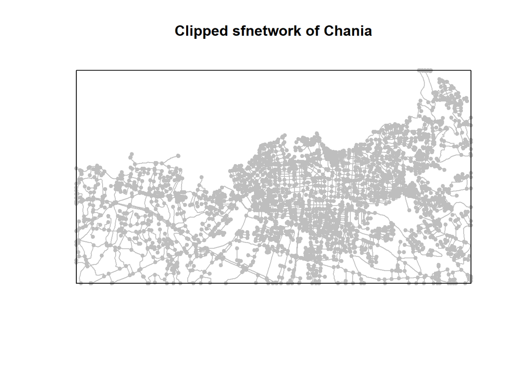

```r
poly = goal::osm.bb_2_pol(q, outcrs =  4326) # bbox σε spatial polygon
net3 = goal::osm.ClipSFnetwork_with_poly(net2, poly) # clip network by spatial polygon

plot(net3,col="grey", main="Clipped sfnetwork of Chania")
plot(poly,add=T)
```

```r
# Create a random point
#gps = sfheaders::sf_point(data.frame(y = 26.55257, x = 39.10575, ID=-1))  %>% st_set_crs(4326)

# nearest edge (road) to the point. The network must have edges activated.
#near_edge = st_nearest_feature(gps, net3 %>% st_as_sf())

#near_edge
#st_as_sf(net3)[near_edge,]

#p3 = ggplot() +
#geom_sf(data = st_as_sf(net3), color = 'black') +
#geom_sf(data = gps, color = 'red') +
#geom_sf(data = st_as_sf(net3)[near_edge,], color = 'orange')
#p3
#plot(net3)
#net3
```

Non-Isolated Nodes

```r
net3 %>%  sfnetworks::activate("nodes") %>% dplyr::filter(!tidygraph::node_is_isolated())
```

```
## # A sfnetwork with 3851 nodes and 2128 edges
## #
## # CRS:  EPSG:4326
## #
## # A directed acyclic simple graph with 1726 components with spatially explicit edges
## #
## # Node data: 3,851 × 1 (active)
##              geometry
##           <POINT [°]>
## 1 (24.02499 35.51064)
## 2 (24.02294 35.51349)
## 3 (24.02119 35.51146)
## 4 (24.02025 35.51258)
## 5 (24.02968 35.51043)
## 6 (24.05179 35.52471)
## # ℹ 3,845 more rows
## #
## # Edge data: 2,128 × 6
##    from    to osm_id  name              highway                         geometry
##   <int> <int> <chr>   <chr>             <chr>                   <LINESTRING [°]>
## 1  1938     1 5738798 Νεάρχου           secondary   (24.02504 35.50692, 24.0250…
## 2     2     3 5738801 Μπονιάλη Κτιστάκη residential (24.02294 35.51349, 24.0224…
## 3  1939     4 5738803 Αποκορώνου        secondary   (24.01965 35.51346, 24.0196…
## # ℹ 2,125 more rows
```

Isolated Nodes

```r
net3 %>% sfnetworks::activate("nodes") %>% dplyr::filter(tidygraph::node_is_isolated()) %>% st_as_sf() %>% nrow()
```

```
## [1] 0
```

Loop Edges

```r
net3 %>% sfnetworks::activate("edges") %>% dplyr::filter(tidygraph::edge_is_loop()) %>% st_as_sf() %>% nrow()
```

```
## [1] 0
```

Multiple Edges (has any parallel siblings)

```r
net3 %>% sfnetworks::activate("edges") %>% dplyr::filter(tidygraph::edge_is_multiple()) %>% st_as_sf() %>% nrow()
```

```
## [1] 0
```

Simplify network.

```r
net3b = net3 %>% activate("edges") %>%
  filter(!edge_is_multiple()) %>%
  filter(!edge_is_loop())
```

# 2 Ενσωμάτωση των σημείων

Κατασκευή τοπολογικά ορθού δικτύου (net4) από τα κατεβασμένα δεδομένα της περιοχής μελέτης.  
[Subdivide network](https://luukvdmeer.github.io/sfnetworks/articles/sfn02_preprocess_clean.html#subdivide-edges) [Smooth pseudo nodes](https://luukvdmeer.github.io/sfnetworks/articles/sfn02_preprocess_clean.html#smooth-pseudo-nodes)

```r
net4 = tidygraph::convert(net3b, to_spatial_subdivision)
net4 = tidygraph::convert(net4, to_spatial_smooth)
net4 = tidygraph::convert(net4, to_spatial_simple)
```

Πόσοι κόμβοι στο δίκτυο μας (nodes)?

```r
n_nodes = net4 %>% activate(nodes) %>% st_as_sf()%>% nrow()
```

Σε κάθε δρόμο (edges) πρόσθεσε μια νέα στήλη “length” με το μήκος του κάθε δρόμου.

```r
net4 = net4 %>% activate(edges) %>%
  mutate(length = edge_length())%>% st_set_crs(4326)
```

Σε κάθε κόμβο (nodes), πρόσθεσε μια νέα στήλη “ID” αλλά και μια νέα στήλη “ishouse”=1.

```r
net4 = net4 %>% activate(nodes) %>%
  mutate(ID = 1:n_nodes)%>%
  mutate(ishouse = 1)%>% st_set_crs(4326)
```

Αυτά είναι τα επιλεγμένα σημεία καταφυγής μας. Τα βρήκαμε από το GoogleΜaps και μπορεί να είναι πάρκα, εκκλησίες, σχολεία, γήπεδα.

```r
gps1 = sfheaders::sf_point(data.frame(y =23.976000, x =35.506798))  %>% st_set_crs(4326)
gps2 = sfheaders::sf_point(data.frame(y =23.995920, x =35.499531 ))  %>% st_set_crs(4326)
gps3 = sfheaders::sf_point(data.frame(y =24.016876, x =35.509592 ))  %>% st_set_crs(4326)
gps4 = sfheaders::sf_point(data.frame(y =24.046765, x =35.511828))  %>% st_set_crs(4326)


mycol = c("blue","green",'red',"purple")
evac_points = rbind(gps1, gps2, gps3,gps4) #%>% rowid_to_column() # Νέα στήλη 'rowid'
```

Ενσωμάτωση των χώρων καταφυγής, στο δίκτυο μας ως 4 νέους κόμβους (nodes):

```r
blended = st_network_blend(net4, evac_points  )
```

Άλλαξε τις τιμές των στηλών: ‘isevac’, ‘ishouse’ ανάλογα:

```r
blended = blended %>% activate(nodes) %>%
  mutate(isevac = ifelse(is.na(ishouse), 1, 0) ) %>%
  mutate(ishouse = ifelse(is.na(ishouse), 0, 1) )
```

Οι 10 τελευταίοι κόμβοι (nodes) του δικτύου μας μέχρι στιγμής. Φαίνονται οι 4 νέοι κόμβοι (nodes) `isevac = 1`

```r
blended %>%  activate("nodes") %>% st_as_sf() %>% as.data.frame() %>% tail(10)
```

```
##                       geometry .tidygraph_node_index   ID ishouse isevac
## 3131 POINT (24.00446 35.49387)                  3131 3131       1      0
## 3132  POINT (24.05312 35.4931)                  3132 3132       1      0
## 3133 POINT (24.00385 35.51132)                  3133 3133       1      0
## 3134 POINT (24.05049 35.49514)                  3134 3134       1      0
## 3135  POINT (23.9639 35.49405)                  3135 3135       1      0
## 3136  POINT (23.9639 35.49361)                  3136 3136       1      0
## 3137  POINT (23.9761 35.50642)                    NA   NA       0      1
## 3138 POINT (24.01688 35.50938)                    NA   NA       0      1
## 3139   POINT (24.04682 35.512)                    NA   NA       0      1
## 3140 POINT (23.99585 35.49946)                    NA   NA       0      1
```

Αφαίρεση των disconnected

```r
table(components(blended)$membership)
```

```
##
##    1    2    3    4    5    6    7    8    9   10   11   12
## 3082   10    6   24    4    2    2    2    2    2    2    2
```

```r
blended = blended %>% activate('nodes')%>%
  filter(components(blended)$membership == 1)
```

# 3 Ανάθεση

Το δίκτυο μέχρι στιγμής:

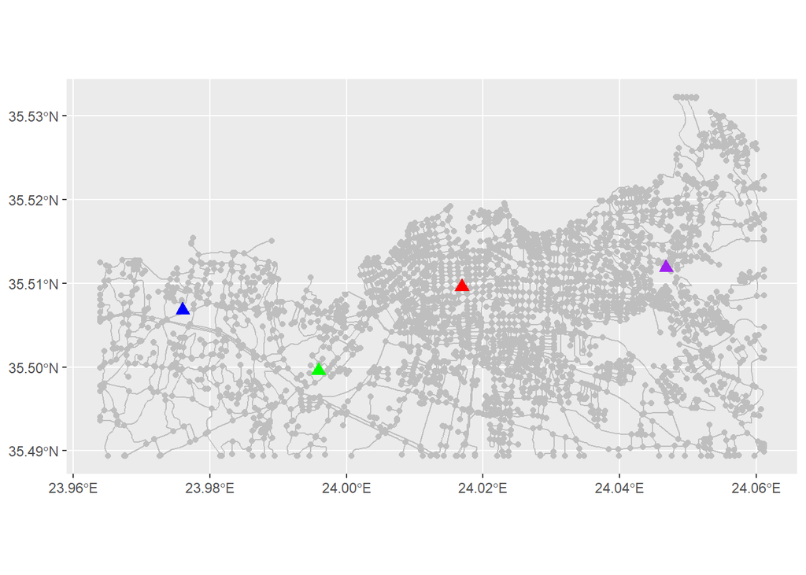

```r
ggplot() +
  geom_sf(data = st_as_sf(net4%>%  activate("edges")), color = 'grey') +
  geom_sf(data = st_as_sf(net4%>%  activate("nodes")), color = 'grey')+
  geom_sf(data = evac_points, color = mycol, cex=3, pch=17)
```

Τα ‘rowids’ των χώρων καταφυγής `isevac=1` :

```r
rowids_evac = blended %>%  activate("nodes") %>% as.data.frame() %>%  rowid_to_column() %>% filter(isevac == 1) %>% pull(rowid)
tail(rowids_evac)
```

```
## [1] 3079 3080 3081 3082
```

Τα ‘rowids’ των σπιτιών `ishouse=1` :

```r
rowids_houses = blended %>%  activate("nodes") %>% as.data.frame() %>%  rowid_to_column() %>% filter(ishouse == 1) %>% pull(rowid)
tail(rowids_houses)
```

```
## [1] 3073 3074 3075 3076 3077 3078
```

```r
evac_sf = blended %>%  activate("nodes") %>% st_as_sf() %>% filter(isevac==1)
houses_sf = blended %>%  activate("nodes") %>% st_as_sf() %>% filter(ishouse==1)   #%>% rowid_to_column()
```

Πόσοι δρόμοι (edges)?

```r
n_edges =  blended %>% activate(edges)  %>% st_as_sf()%>%  nrow()
```

Δημιουργία στήλης σε κάθε δρόμο (edge) με τίτλο στήλης `IDedge`

```r
blended = blended %>% activate(edges) %>% mutate(IDedge = 1:n_edges)
```

Υπολογισμός του **Distance Matrix** :

```r
dm = st_network_cost(blended, from =rowids_houses , to =rowids_evac ,  direction="all")
head(dm)
```

```
## Units: [m]
##          [,1]     [,2]     [,3]     [,4]
## [1,] 4853.665 980.0194 2640.836 3342.103
## [2,] 4748.423 874.7771 2540.399 3236.861
## [3,] 4708.623 810.6987 2437.149 3197.062
## [4,] 4754.572 858.6964 2422.334 3243.010
## [5,] 4716.059 820.1837 2341.662 3204.497
## [6,] 4686.025 825.8693 2548.788 3174.463
```

Για κάθε σπίτι, εύρεση ποιου από τους 4 χώρους καταφυγής είναι πιο κοντά. Για κάθε σπίτι, κατασκευή δυο νέων στηλών:

- **closest_index**: Ποιος χώρος καταφυγής είναι πιο κοντά?
- **closest_index_dist**: Σε τι απόσταση είναι ο πιο κοντινός χώρος καταφυγής?

```r
houses_sf$closest_index = apply(dm, 1, function(x) which(x == min(x))[1])
houses_sf$closest_index_dist = apply(dm, 1, function(x)  min(x)[1])
```

Οπτικοποίηση τελικής ανάθεσης στους 4 χώρους καταφυγής:

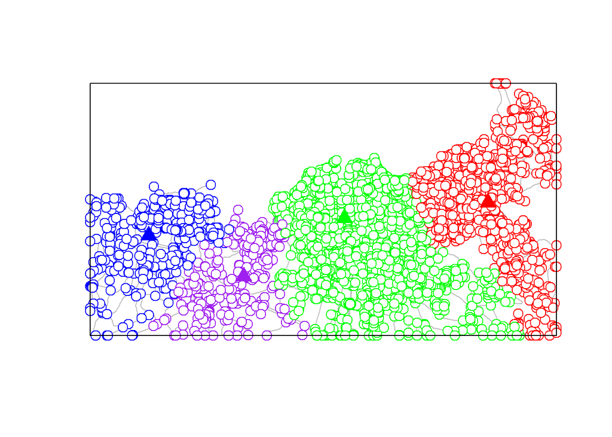

```r
plot(blended, col="grey")
plot(st_geometry(houses_sf), cex=1.5, col=mycol[houses_sf$closest_index], pch=21, add=T)
plot(st_geometry(evac_sf) , cex=2, pch=17, add=T, col=mycol)
plot(poly, add=T)
```

## 3.1 Στατιστικά ανάθεσης

Πόσοι κόμβοι ανατέθηκαν σε κάθε χώρο καταφυγής?

```r
table(houses_sf$closest_index)
```

```
##
##    1    2    3    4
##  348 1518  923  289
```

Απόσταση μεταξύ κόμβων και χώρων καταφυγής (Ελάχιστη, Μέγιστη, Μέσος Όρος):

```r
houses_sf %>% as.data.frame()%>% group_by(closest_index) %>%
  summarise( min_dist=min(closest_index_dist),
             max_dist=max(closest_index_dist),
             mean_dist=mean(closest_index_dist) )
```

```
## # A tibble: 4 × 4
##   closest_index min_dist max_dist mean_dist
##           <int>    <dbl>    <dbl>     <dbl>
## 1             1    151.     2644.     1161.
## 2             2     43.4    4323.     1482.
## 3             3     42.7    4260.     1615.
## 4             4     92.9    2784.     1273.
```

# 4 Περιορισμός απόστασης

Ορισμός μιας μεγίστης απόστασης περπατήματος.

```r
apostasi = 800

dm2 = dm
dm2 = units::drop_units(dm2) #  Αφαίρεση μονάδων μέτρησης από το Distance Matrix
dm2[dm2>=apostasi] = NA


houses_sf$closest_index2 = apply(dm2, 1, function(x) which(x == min(x, na.rm=T))[1])
houses_sf$closest_index_dist2 = apply(dm2, 1, function(x)  min(x, na.rm=T)[1])
```

Οπτικοποίηση τελικής ανάθεσης στους 4 χώρους καταφυγής:

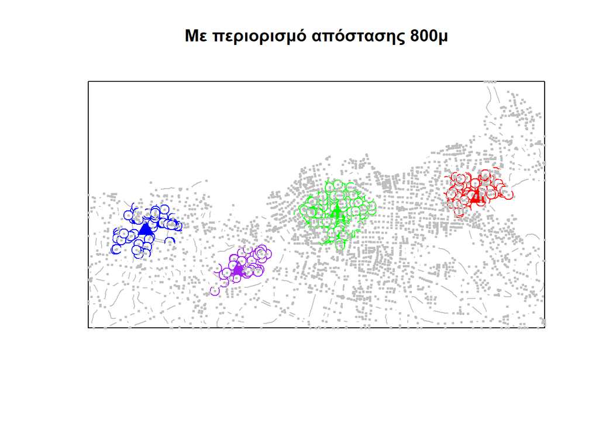

```r
plot(blended, col="grey", main = sprintf("Με περιορισμό απόστασης %sμ", apostasi))
plot(st_geometry(houses_sf), cex=1.5, col=mycol[houses_sf$closest_index2],  pch=21, add=T)
plot(st_geometry(evac_sf) , cex=2, pch=17, add=T, col=mycol)
plot(poly, add=T)
plot(st_geometry(houses_sf),cex=0.5, add=T, col="grey", pch=20)
```

Πόσοι κόμβοι δεν εξυπηρετούνται?

```r
table(houses_sf$closest_index2,  useNA="ifany")
```

```
##
##    1    2    3    4 <NA>
##   74  266  132   43 2563
```

# 5 Περιορισμός πλήθους

Κάθε χώρος καταφυγής μπορεί να εξυπηρετήσει μόνο μέχρι 55 άτομα.

```r
dm3 = dm

df = as.data.frame(dm3)
df$whichMin = apply(dm3, 1, which.min)
df$minDistance = apply(dm3, 1, FUN=min, na.rm=T)
```

Ιεράρχηση ανά γκρούπ

```r
library(dplyr)
df3 = df %>%
  group_by(whichMin) %>%
  mutate(my_ranks = order(order(minDistance, decreasing=F)))


df3
```

```
## # A tibble: 3,078 × 7
## # Groups:   whichMin [4]
##       V1   V2    V3    V4 whichMin minDistance my_ranks
##      [m]  [m]   [m]   [m]    <int>       <dbl>    <int>
##  1 4854. 980. 2641. 3342.        2        980.      417
##  2 4748. 875. 2540. 3237.        2        875.      324
##  3 4709. 811. 2437. 3197.        2        811.      276
##  4 4755. 859. 2422. 3243.        2        859.      306
##  5 4716. 820. 2342. 3204.        2        820.      282
##  6 4686. 826. 2549. 3174.        2        826.      285
##  7 4632. 736. 2638. 3121.        2        736.      224
##  8 4562. 666. 2675. 3051.        2        666.      168
##  9 4439. 543. 2742. 2927.        2        543.      107
## 10 4371. 622. 2807. 2860.        2        622.      148
## # ℹ 3,068 more rows
```

```r
df3$whichMin2 = NA
df3[df3$whichMin==1 & df3$my_ranks %in% c(1:55),]$whichMin2 = 1
df3[df3$whichMin==2 & df3$my_ranks %in% c(1:55),]$whichMin2 = 2
df3[df3$whichMin==3 & df3$my_ranks %in% c(1:55),]$whichMin2 = 3
df3[df3$whichMin==4 & df3$my_ranks %in% c(1:55),]$whichMin2 = 4

houses_sf$closest_index3 = df3$whichMin2
```

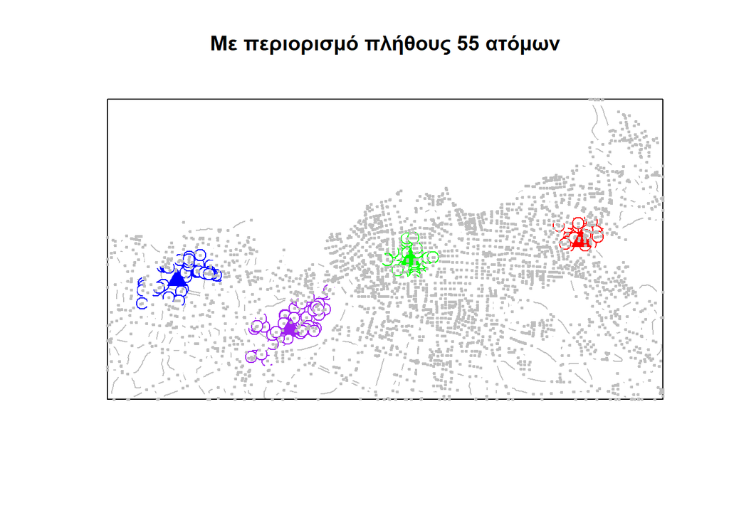

```r
plot(blended, col="grey", main = sprintf("Με περιορισμό πλήθους %s ατόμων", 55))
plot(st_geometry(houses_sf), cex=1.5, col=mycol[houses_sf$closest_index3],  pch=21, add=T)
plot(st_geometry(evac_sf) , cex=2, pch=17, add=T, col=mycol)
plot(poly, add=T)
plot(st_geometry(houses_sf),cex=0.5, add=T, col="grey", pch=20)
```

Απόσταση μεταξύ κόμβων και χώρων καταφυγής (Ελάχιστη, Μέγιστη, Μέσος Όρος):

```r
houses_sf %>% as.data.frame()%>% group_by(closest_index2) %>%
  summarise( min_dist=min(closest_index_dist2),
             max_dist=max(closest_index_dist2),
             mean_dist=mean(closest_index_dist2) )
```

```
## # A tibble: 5 × 4
##   closest_index2 min_dist max_dist mean_dist
##            <int>    <dbl>    <dbl>     <dbl>
## 1              1    151.      797.      603.
## 2              2     43.4     798.      563.
## 3              3     42.7     800.      535.
## 4              4     92.9     796.      484.
## 5             NA    Inf       Inf       Inf
```

# 6 Πηγαίος κώδικας

```r
#'
#library(remotes)
#library(devtools)
#remotes::install_version("rgeos", version = "0.6-4")
#remotes::install_version("simplevis", version = "7.1.0")
#devtools::install_github("dimitrisk/goal", force=T)
#'
#1
#library(remotes)
#library(devtools)
#library(sf)
#library(tidygraph)
#library(igraph)
#library(dplyr)
#library(tibble)
#library(ggplot2)
#library(units)
#library(tmap)
#library(osmdata)
#library(link2GI)
#library(nabor)
#library(units)
#library(sfnetworks)
#library(dplyr)
#library(goal)

# Δεδομένα δικτύου
#q = c(23.9639, 35.4894, 24.0611, 35.5322) # Bounding Box πόλης Χανίων
#net2 = goal::osm.getRoads(q, withBB=TRUE, outcrs=4326)

#poly = goal::osm.bb_2_pol(q, outcrs =  4326) # bbox σε spatial polygon
#net3 = goal::osm.ClipSFnetwork_with_poly(net2, poly) # clip network by spatial polygon

#plot(net3,col="grey", main="Clipped sfnetwork of Chania")
#plot(poly,add=T)

# Create a random point
#gps = sfheaders::sf_point(data.frame(y = 26.55257, x = 39.10575, ID=-1))  %>% st_set_crs(4326)

# nearest edge (road) to the point. The network must have edges activated.
#near_edge = st_nearest_feature(gps, net3 %>% st_as_sf())

#near_edge
#st_as_sf(net3)[near_edge,]

#p3 = ggplot() +
#geom_sf(data = st_as_sf(net3), color = 'black') +
#geom_sf(data = gps, color = 'red') +
#geom_sf(data = st_as_sf(net3)[near_edge,], color = 'orange')
#p3
#plot(net3)
#net3

#net3 %>%  sfnetworks::activate("nodes") %>% #dplyr::filter(!tidygraph::node_is_isolated())

#net3 %>% sfnetworks::activate("nodes") %>% dplyr::filter(tidygraph::node_is_isolated()) %>% st_as_sf() %>% nrow()

#net3 %>% sfnetworks::activate("edges") %>% dplyr::filter(tidygraph::edge_is_loop()) %>% st_as_sf() %>% nrow()

#net3 %>% sfnetworks::activate("edges") %>% dplyr::filter(tidygraph::edge_is_multiple()) %>% st_as_sf() %>% nrow()

#net3b = net3 %>% activate("edges") %>%
#  filter(!edge_is_multiple()) %>%
#  filter(!edge_is_loop())

# Ενσωμάτωση των σημείων

#net4 = tidygraph::convert(net3b, to_spatial_subdivision)
#net4 = tidygraph::convert(net4, to_spatial_smooth)
#net4 = tidygraph::convert(net4, to_spatial_simple)

#n_nodes = net4 %>% activate(nodes) %>% st_as_sf()%>% nrow()

#net4 = net4 %>% activate(edges) %>%
#  mutate(length = edge_length())%>% st_set_crs(4326)

#net4 = net4 %>% activate(nodes) %>%
#  mutate(ID = 1:n_nodes)%>%
#  mutate(ishouse = 1)%>% st_set_crs(4326)

#gps1 = sfheaders::sf_point(data.frame(y =23.976000, x =35.506798))  %>% st_set_crs(4326)
#gps2 = sfheaders::sf_point(data.frame(y =23.995920, x =35.499531 ))  %>% st_set_crs(4326)
#gps3 = sfheaders::sf_point(data.frame(y =24.016876, x =35.509592 ))  %>% st_set_crs(4326)
#gps4 = sfheaders::sf_point(data.frame(y =24.046765, x =35.511828))  %>% st_set_crs(4326)

#mycol = c("blue","green",'red',"purple")
#evac_points = rbind(gps1, gps2, gps3,gps4) #%>% rowid_to_column() # Νέα στήλη 'rowid'

#blended = st_network_blend(net4, evac_points  )

#blended = blended %>% activate(nodes) %>%
#  mutate(isevac = ifelse(is.na(ishouse), 1, 0) ) %>%
#  mutate(ishouse = ifelse(is.na(ishouse), 0, 1) )

#blended %>%  activate("nodes") %>% st_as_sf() %>% as.data.frame() %>% tail(10)

#table(components(blended)$membership)

#blended = blended %>% activate('nodes')%>%
#  filter(components(blended)$membership == 1)

# Ανάθεση

#ggplot() +
#  geom_sf(data = st_as_sf(net4%>%  activate("edges")), color = 'grey') +
#  geom_sf(data = st_as_sf(net4%>%  activate("nodes")), color = 'grey')+
#  geom_sf(data = evac_points, color = mycol, cex=3, pch=17)

#rowids_evac = blended %>%  activate("nodes") %>% as.data.frame() %>%  rowid_to_column() %>% filter(isevac == 1) %>% pull(rowid)
#tail(rowids_evac)

#rowids_houses = blended %>%  activate("nodes") %>% as.data.frame() %>%  rowid_to_column() %>% filter(ishouse == 1) %>% pull(rowid)
#tail(rowids_houses)

#evac_sf = blended %>%  activate("nodes") %>% st_as_sf() %>% filter(isevac==1)
#houses_sf = blended %>%  activate("nodes") %>% st_as_sf() %>% filter(ishouse==1)   #%>% rowid_to_column()

#n_edges =  blended %>% activate(edges)  %>% st_as_sf()%>%  nrow()

#blended = blended %>% activate(edges) %>% mutate(IDedge = 1:n_edges)

#dm = st_network_cost(blended, from =rowids_houses , to =rowids_evac ,  direction="all")
#head(dm)

#houses_sf$closest_index = apply(dm, 1, function(x) which(x == min(x))[1])
#houses_sf$closest_index_dist = apply(dm, 1, function(x)  min(x)[1])

#plot(blended, col="grey")
#plot(st_geometry(houses_sf), cex=1.5, col=mycol[houses_sf$closest_index], pch=21, add=T)
#plot(st_geometry(evac_sf) , cex=2, pch=17, add=T, col=mycol)
#plot(poly, add=T)

## Στατιστικά ανάθεσης

#table(houses_sf$closest_index)

#houses_sf %>% as.data.frame()%>% group_by(closest_index) %>%
#  summarise( min_dist=min(closest_index_dist),
#             max_dist=max(closest_index_dist),
#             mean_dist=mean(closest_index_dist) )

# Περιορισμός απόστασης

#apostasi = 800

#dm2 = dm
#dm2 = units::drop_units(dm2) #  Αφαίρεση μονάδων μέτρησης από το Distance Matrix
#dm2[dm2>=apostasi] = NA

#houses_sf$closest_index2 = apply(dm2, 1, function(x) which(x == min(x, na.rm=T))[1])
#houses_sf$closest_index_dist2 = apply(dm2, 1, function(x)  min(x, na.rm=T)[1])

#plot(blended, col="grey", main = sprintf("Με περιορισμό απόστασης %sμ", apostasi))
#plot(st_geometry(houses_sf), cex=1.5, col=mycol[houses_sf$closest_index2],  pch=21, add=T)
#plot(st_geometry(evac_sf) , cex=2, pch=17, add=T, col=mycol)
#plot(poly, add=T)
#plot(st_geometry(houses_sf),cex=0.5, add=T, col="grey", pch=20)

#table(houses_sf$closest_index2,  useNA="ifany")

# Περιορισμός πλήθους

#dm3 = dm

#df = as.data.frame(dm3)
#df$whichMin = apply(dm3, 1, which.min)
#df$minDistance = apply(dm3, 1, FUN=min, na.rm=T)

#library(dplyr)
#df3 = df %>%
#  group_by(whichMin) %>%
#  mutate(my_ranks = order(order(minDistance, decreasing=F)))


#df3

#df3$whichMin2 = NA
#df3[df3$whichMin==1 & df3$my_ranks %in% c(1:55),]$whichMin2 = 1
#df3[df3$whichMin==2 & df3$my_ranks %in% c(1:55),]$whichMin2 = 2
#df3[df3$whichMin==3 & df3$my_ranks %in% c(1:55),]$whichMin2 = 3
#df3[df3$whichMin==4 & df3$my_ranks %in% c(1:55),]$whichMin2 = 4

#houses_sf$closest_index3 = df3$whichMin2

#plot(blended, col="grey", main = sprintf("Με περιορισμό πλήθους %s ατόμων", 55))
#plot(st_geometry(houses_sf), cex=1.5, col=mycol[houses_sf$closest_index3],  pch=21, add=T)
#plot(st_geometry(evac_sf) , cex=2, pch=17, add=T, col=mycol)
#plot(poly, add=T)
#plot(st_geometry(houses_sf),cex=0.5, add=T, col="grey", pch=20)

#houses_sf %>% as.data.frame()%>% group_by(closest_index2) %>%
#  summarise( min_dist=min(closest_index_dist2),
#             max_dist=max(closest_index_dist2),
#             mean_dist=mean(closest_index_dist2) )
```

# 7 Βιβλιογραφία

- Καβρουδάκης, Δ. (2022) ΠΠΣ Γεωγραφική Ανάλυση (ΓΕΟ 302).
  - Διαθέσιμο στο: [Open eClass, Πανεπιστήμιο Αιγαίου](https://eclass.aegean.gr/courses/GEO157/)
  - (Πρόσβαση: 14/01/2025).

[figure not shown]